# transition to multiple states

```r
library(deSolve)
library(denim)
```

## 1. Transition to multiple states in denim

Modelers may encounter many situations where individuals can transition from one compartment to multiple others, such as the SIRD model. There are 2 main approaches to handle this:

- Model transitions as competing risks
- Model as multinomial transition (outgoing population is split by a fixed proportion to transition to new compartments).

`denim` allows the users to model both situations, while requiring minimal change to the code base to switch between 2 methods of modeling.

## 2. Multinomial in denim

### 2.1. Model definition

To specify the proportion that goes to each outgoing compartment, define the transition using the following syntax in model definition:

`proportion * from -> to = [transition]`

Note that the `proportion` here is the proportion of `compartment` that will end up in `out_compartment` at equilibrium.

*Example:* An SIRD model where 90% of infected can recover while the remaining 10% will die.

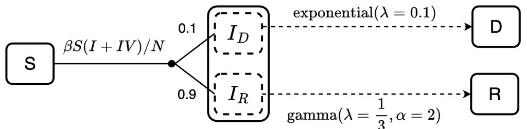

```r
transitions <- denim_dsl({
  S -> I = beta * S * (I / N)
  0.9 * I -> R = d_gamma(1/3, 2)
  0.1 * I -> D = d_exponential(0.1)
})
```

**Mathematical formulation for the model**

$$\begin{cases}
dS = -\beta S \frac{I}{N} \\
dIR_1 = 0.9 *\beta S \frac{I}{N} -\frac{1}{3}IR_1 \\
dIR_2 = \frac{1}{3}IR_1 - \frac{1}{3}IR_2 \\
dID = 0.1*\beta S \frac{I}{N} - 0.1*ID \\
dR = \frac{1}{3}IR_2 \\
dD = 0.1*ID
\end{cases}$$

#### Proportion normalization

`denim` will automatically normalize the proportions if they don’t sum up to 1.

*Example 2:* The following model definition is equivalent to the one in *Example 1*

```r
transitions <- denim_dsl({
  S -> I = beta * S * (I / N)
  36 * I -> R = d_gamma(1/3, 2)
  4 * I -> D = d_exponential(0.1)
})
```

### 2.2. Example model

To further demonstrate the implementation of multinomial in `denim`, we provide the equivalent model implemented in `deSolve` and compare the output of 2 implementations.

#### Model definition in denim

```r
# model in denim
transitions <- denim_dsl({
  S -> I = beta * S * (I / N)
  0.9 * I -> R = d_gamma(1/3, 2)
  0.1 * I -> D = d_exponential(0.1)
})

denimInitialValues <- c(
  S = 999,
  I = 1,
  R = 0,
  D = 0
)
```

#### Equivalent model definition in deSolve

```r
# model in deSolve
transition_func <- function(t, state, param){
  with(as.list( c(state, param) ), {

      dS = - beta * S * (IR1 + IR2 + ID)/N
      # apply linear chain trick for I -> R transition
      # 0.9 * to specify prop of I that goes to I->R transition
      dIR1 = 0.9 * beta * S * (IR1 + IR2 + ID)/N - rate*IR1
      dIR2 = rate*IR1 - rate*IR2
      dR = rate*IR2

      # handle I -> D transition
      # 0.1 * to specify prop of I that goes to I->D transition
      dID = 0.1 * beta * S * (IR1 + IR2 + ID)/N - exp_rate*ID
      dD = exp_rate*ID
      list(c(dS, dIR1, dIR2, dID, dR, dD))
  })
}

desolveInitialValues <- c(
  S = 999,
  # note that internally, denim also allocate initial value based on specified proportion
  IR1 = 0.9,
  IR2 = 0,
  ID = 0.1,
  R = 0,
  D = 0
)
```

#### Run simulation and compare

**Model settings**

```r
parameters <- c(
  beta = 0.2,
  N = 1000,
  rate = 1/3,
  exp_rate = 0.1
)

simulationDuration <- 200
timeStep <- 0.05
```

**Run model**

```r
# --- run denim model ----
mod <- sim(transitions = transitions,
           initialValues = denimInitialValues,
           parameters = parameters,
           simulationDuration = simulationDuration,
           timeStep = timeStep)

# run deSolve model
times <- seq(0, simulationDuration)
ode_mod <- ode(y = desolveInitialValues, times = times, parms = parameters, func = transition_func)
ode_mod <- as.data.frame(ode_mod)
ode_mod$I<- rowSums(ode_mod[, c("IR1", "IR2", "ID")])
```

Output Comparison

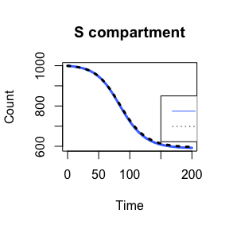

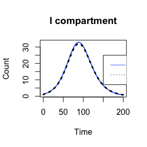

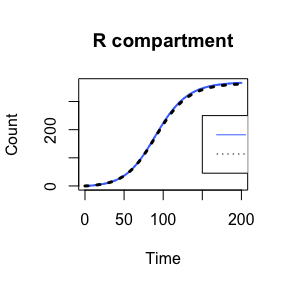

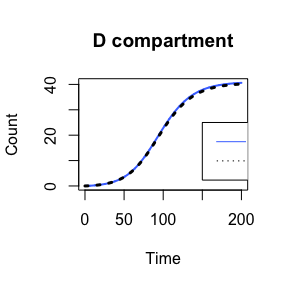

## 3. Competing risks in denim

### 3.1. Model definition

When there are multiple transitions from one compartment and no proportions are specified, denim will automatically treat these transitions as competing risks.

*Example:* the following model definition will treat `I->R` and `I->D` as competing risks.

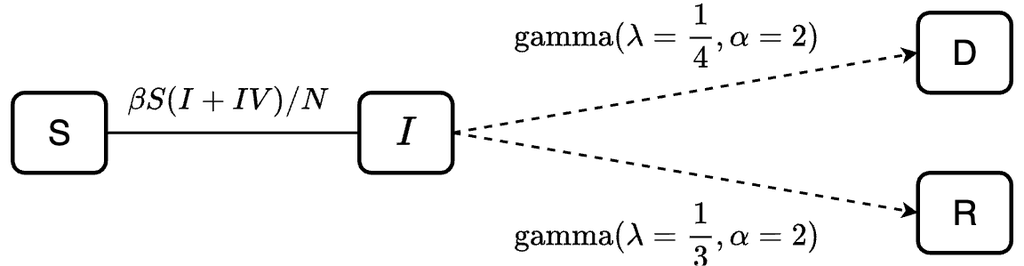

```r
transitions <- denim_dsl({
  S -> I = beta * S * (I / N)
  I -> R = d_gamma(rate = 1/3, shape = 2)
  I -> D = d_gamma(rate = 1/4, shape = 2)
})
```

### 3.2. Example model

To further demonstrate the implementation of competing risks in `denim`, we provide the equivalent model implemented in `deSolve` and compare the output of 2 implementations.

#### Model definition in denim

```r
transitions <- denim_dsl({
  S -> I = beta * S * (I / N)
  I -> R = d_gamma(rate = 1/3, shape = 2)
  I -> D = d_gamma(rate = 1/4, shape = 2)
})

denimInitialValues <- c(
  S = 950,
  I = 50,
  R = 0,
  D = 0
)
```

#### Equivalent model definition in deSolve

```r
transition_func <- function(t, state, param){
  with(as.list( c(state, param) ), {
    dS = - beta * S * (I1 + I2 + IR + ID)/N

    dI1 = beta * S * (I1 + I2 + IR + ID)/N - (rate+d_rate)*I1

    dIR = rate*I1 - (d_rate + rate)*IR
    dID = d_rate*I1 - (d_rate + rate)*ID

    dI2 = d_rate*IR + rate*ID - (d_rate + rate)*I2

    dR = rate*IR + rate*I2
    dD = d_rate*ID + d_rate*I2

    list(c(dS, dI1, dIR, dID, dI2, dR, dD))
  })
}

desolveInitialValues <- c(
  S = 950,
  I1 = 50,
  IR = 0,
  ID = 0,
  I2 = 0,
  R = 0,
  D = 0
)
```

#### Run simulation and compare

**Model settings**

```r
parameters <- c(
  beta = 0.2,
  N = 1000,
  rate = 1/3,
  d_rate = 1/4
)

simulationDuration <- 50
timeStep <- 0.05
```

**Run model**

```r
# run denim model
mod <- sim(transitions = transitions,
           initialValues = denimInitialValues,
           parameters = parameters,
           simulationDuration = simulationDuration,
           timeStep = timeStep)

# run deSolve model
times <- seq(0, simulationDuration)
ode_mod <- ode(y = desolveInitialValues, times = times, parms = parameters, func = transition_func)
ode_mod <- as.data.frame(ode_mod)
ode_mod$I <- rowSums(ode_mod[,c("I1", "ID", "IR", "I2")])
```

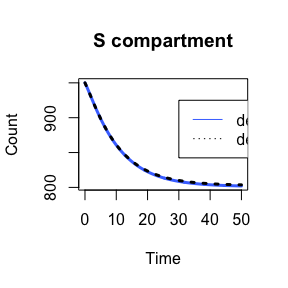

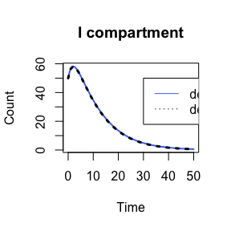

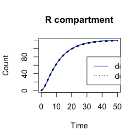

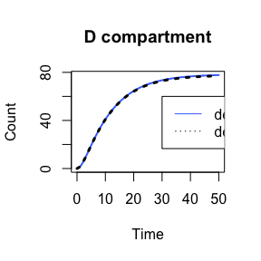